# Heterogeneity & Demographic Analysis

2017-04-07

## Introduction

Heterogeneity analysis is a way to explore how the results of a model can vary depending on the characteristics of individuals in a population, and demographic analysis estimates the average values of a model over an entire population.

In practice these two analyses naturally complement each other: heterogeneity analysis runs the model on multiple sets of parameters (reflecting differents characteristics found in the target population), and demographic analysis combines the results.

For this example we will use the result from the assessment of a new total hip replacement previously described in `vignette("d-non-homogeneous", "heemod")`.

## Population characteristics

The characteristics of the population are input from a table, with one column per parameter and one row per individual. Those may be for example the characteristics of the indiviuals included in the original trial data.

For this example we will use the characteristics of 100 individuals, with varying sex and age, specified in the data frame `tab_indiv`:

```r
tab_indiv
```

```
## # A tibble: 100 × 2
##      age   sex
##    <dbl> <int>
## 1     63     1
## 2     63     1
## 3     73     1
## 4     51     1
## 5     63     1
## 6     50     1
## 7     73     0
## 8     56     1
## 9     57     0
## 10    58     0
## # ... with 90 more rows
```

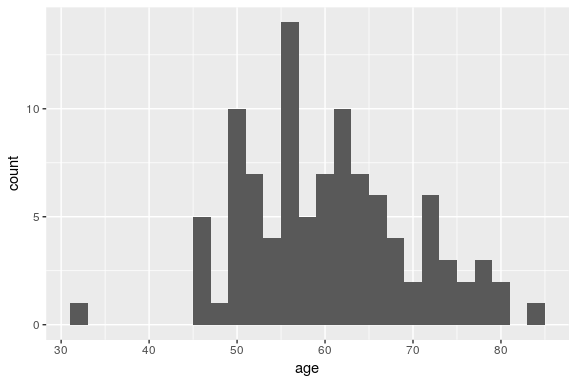

```r
library(ggplot2)
ggplot(tab_indiv, aes(x = age)) +
  geom_histogram(binwidth = 2)
```

## Running the analysis

`res_mod`, the result we obtained from `run_model()` in the *Time-varying Markov models* vignette, can be passed to `update()` to update the model with the new data and perform the heterogeneity analysis.

```r
res_h <- update(res_mod, newdata = tab_indiv)
```

```
## No weights specified in update, using equal weights.
```

```
## Updating strategy 'standard'...
```

```
## Updating strategy 'np1'...
```

## Interpreting results

The `summary()` method reports summary statistics for cost, effect and ICER, as well as the result from the combined model.

```r
summary(res_h)
```

```
## An analysis re-run on 100 parameter sets.
##
## * Unweighted analysis.
##
## * Values distribution:
##
##                                  Min.      1st Qu.      Median        Mean
## standard - Cost          485.85297365  613.8364635 665.3485485 700.1065556
## standard - Effect          9.32287610   22.7930050  27.3769142  25.5743852
## standard - Cost Diff.               -            -           -           -
## standard - Effect Diff.             -            -           -           -
## standard - Icer                     -            -           -           -
## np1 - Cost               603.34263272  637.9508204 652.9595311 662.6411135
## np1 - Effect               9.38064927   23.0848338  27.7656911  25.8392225
## np1 - Cost Diff.        -167.83433856 -110.7286273 -12.3890174 -37.4654421
## np1 - Effect Diff.         0.04405769    0.2051119   0.2214442   0.2648373
## np1 - Icer              -355.65308588 -316.4394659 -57.5010098  -1.1709435
##                             3rd Qu.         Max.
## standard - Cost         802.3426777  882.1752204
## standard - Effect        29.0749005   31.1407367
## standard - Cost Diff.             -            -
## standard - Effect Diff.           -            -
## standard - Icer                   -            -
## np1 - Cost              691.6140504  714.3408818
## np1 - Effect             29.5008365   31.6126413
## np1 - Cost Diff.         24.1143568  117.4896591
## np1 - Effect Diff.        0.3499204    0.4719046
## np1 - Icer              115.6325465 2666.7229585
##
## * Combined result:
##
## 2 strategies run for 60 cycles.
##
## Initial state counts:
##
## PrimaryTHR = 1000L
## SuccessP = 0L
## RevisionTHR = 0L
## SuccessR = 0L
## Death = 0L
##
## Counting method: 'end'.
##
## Values:
##
##           utility     cost
## standard 25574.39 700106.6
## np1      25839.22 662641.1
##
## Efficiency frontier:
##
## np1
##
## Differences:
##
##     Cost Diff. Effect Diff.      ICER     Ref.
## np1  -37.46544    0.2648373 -141.4659 standard
```

The variation of cost or effect can then be plotted.

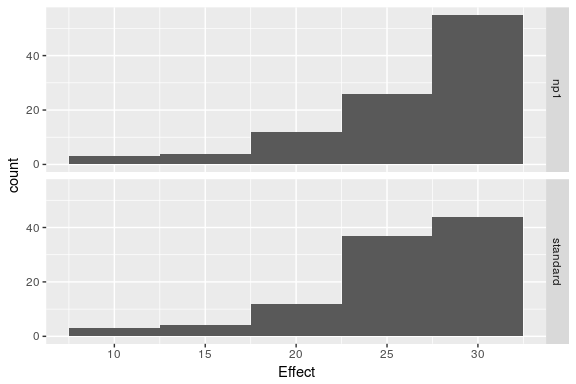

```r
plot(res_h, result = "effect", binwidth = 5)
```

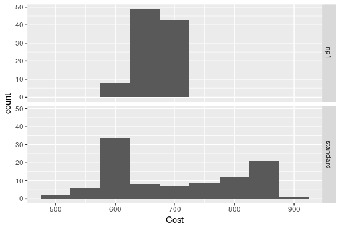

```r
plot(res_h, result = "cost", binwidth = 50)
```

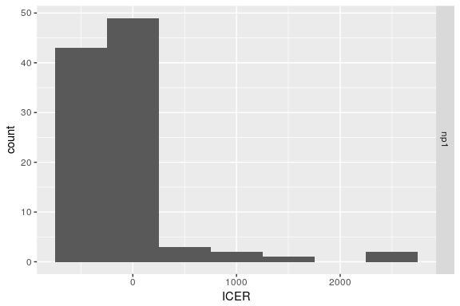

```r
plot(res_h, result = "icer", type = "difference",
     binwidth = 500)
```

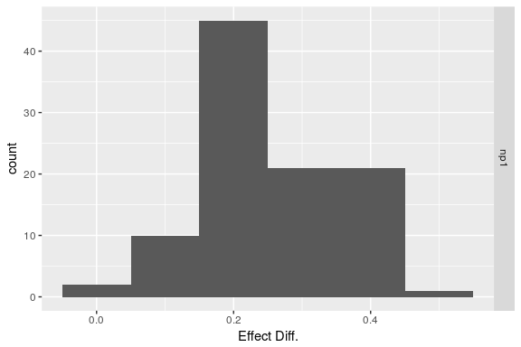

```r
plot(res_h, result = "effect", type = "difference",
     binwidth = .1)
```

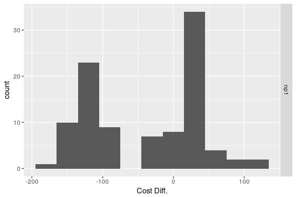

```r
plot(res_h, result = "cost", type = "difference",
     binwidth = 30)
```

The results from the combined model can be plotted similarly to the results from `run_model()`.

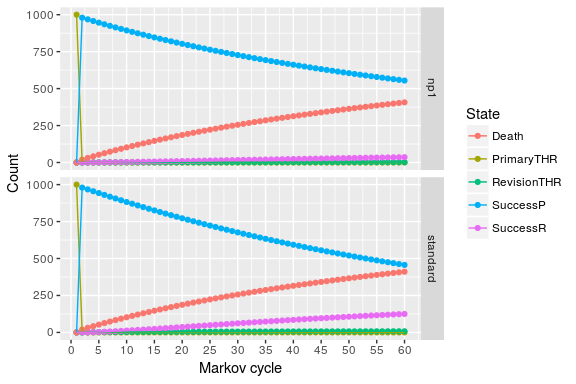

```r
plot(res_h, type = "counts")
```

## Weighted results

Weights can be used in the analysis by including an optional column `.weights` in the new data to specify the respective weights of each strata in the target population.

```r
tab_indiv_w
```

```
## # A tibble: 100 × 3
##      age   sex   .weights
##    <dbl> <int>      <dbl>
## 1     63     0 0.53983643
## 2     62     0 0.57833147
## 3     65     1 0.17316637
## 4     61     0 0.94031598
## 5     46     0 0.01133057
## 6     62     1 0.69021082
## 7     73     0 0.65562913
## 8     55     0 0.35579861
## 9     62     1 0.29374012
## 10    66     1 0.90436778
## # ... with 90 more rows
```

```r
res_w <- update(res_mod, newdata = tab_indiv_w)
```

```
## Updating strategy 'standard'...
```

```
## Updating strategy 'np1'...
```

```r
res_w
```

```
## An analysis re-run on 100 parameter sets.
##
## * Weigths distribution:
##
##     Min.  1st Qu.   Median     Mean  3rd Qu.     Max.
## 0.001342 0.253900 0.506700 0.493200 0.759900 0.992800
##
## Total weight: 49.31926
##
## * Values distribution:
##
##                                  Min.      1st Qu.      Median        Mean
## standard - Cost          530.94590166  605.0062810 622.7847586 678.1247649
## standard - Effect         14.30828698   23.0146204  27.4413633  25.9822442
## standard - Cost Diff.               -            -           -           -
## standard - Effect Diff.             -            -           -           -
## standard - Icer                     -            -           -           -
## np1 - Cost               615.48340627  635.5509751 640.3840220 656.4051279
## np1 - Effect              14.43982318   23.3039321  27.7991788  26.2311556
## np1 - Cost Diff.        -155.93829747 -108.3891499  18.1782873 -21.7196370
## np1 - Effect Diff.         0.09203743    0.1948185   0.2137537   0.2489113
## np1 - Icer              -349.93447295 -313.4504150  82.0897023  52.5296331
##                             3rd Qu.         Max.
## standard - Cost         802.3426777  871.8854128
## standard - Effect        29.0749005   31.3071020
## standard - Cost Diff.             -            -
## standard - Effect Diff.           -            -
## standard - Icer                   -            -
## np1 - Cost              691.6140504  711.4055539
## np1 - Effect             29.5008365   31.5405654
## np1 - Cost Diff.         30.5446941  117.4896591
## np1 - Effect Diff.        0.3499204    0.4556047
## np1 - Icer              156.7853582 2666.7229585
##
## * Combined result:
##
## 2 strategies run for 60 cycles.
##
## Initial state counts:
##
## PrimaryTHR = 1000L
## SuccessP = 0L
## RevisionTHR = 0L
## SuccessR = 0L
## Death = 0L
##
## Counting method: 'end'.
##
## Values:
##
##           utility     cost
## standard 25982.24 678124.8
## np1      26231.16 656405.1
##
## Efficiency frontier:
##
## np1
##
## Differences:
##
##     Cost Diff. Effect Diff.      ICER     Ref.
## np1  -21.71964    0.2489113 -87.25853 standard
```

## Parallel computing

Updating can be significantly sped up by using parallel computing. This can be done in the following way:

- Define a cluster with the `use_cluster()` functions (i.e. `use_cluster(4)` to use 4 cores).
- Run the analysis as usual.
- To stop using parallel computing use the `close_cluster()` function.

Results may vary depending on the machine, but we found speed gains to be quite limited beyond 4 cores.